# Etude des données bruts

##### Premier visionnage des données

```python
import pandas as pd

path="effectifs.csv"
df = pd.read_csv(path, delimiter = ';')
```

```python
df.head()
```

|  | annee | patho_niv1 | patho_niv2 | patho_niv3 | top | cla_age_5 | sexe | region | dept | ntop | npop | prev | niveau_prioritaire | libelle_classe_age | libelle_sexe | tri |
| --- | --- | --- | --- | --- | --- | --- | --- | --- | --- | --- | --- | --- | --- | --- | --- | --- |
| 0 | 2017.0 | Pas de pathologies repérées, traitements, mate... | NaN | NaN | sup_Petit_Conso_exclu | 45-49 | 9.0 | 75 | 999 | 230570.0 | 393250.0 | 58.632 | 1 | de 45 à 49 ans | tous sexes | 17.0 |
| 1 | 2017.0 | Pas de pathologies repérées, traitements, mate... | NaN | NaN | sup_Petit_Conso_exclu | 45-49 | 9.0 | 76 | 11 | 14220.0 | 24330.0 | 58.451 | 1 | de 45 à 49 ans | tous sexes | 17.0 |
| 2 | 2017.0 | Pas de pathologies repérées, traitements, mate... | NaN | NaN | sup_Petit_Conso_exclu | 45-49 | 9.0 | 76 | 12 | 10630.0 | 17390.0 | 61.133 | 1 | de 45 à 49 ans | tous sexes | 17.0 |
| 3 | 2017.0 | Pas de pathologies repérées, traitements, mate... | NaN | NaN | sup_Petit_Conso_exclu | 45-49 | 9.0 | 76 | 30 | 30760.0 | 50820.0 | 60.539 | 1 | de 45 à 49 ans | tous sexes | 17.0 |
| 4 | 2017.0 | Pas de pathologies repérées, traitements, mate... | NaN | NaN | sup_Petit_Conso_exclu | 45-49 | 9.0 | 76 | 48 | 3000.0 | 4920.0 | 60.898 | 1 | de 45 à 49 ans | tous sexes | 17.0 |

```python
df.shape
```

```
(4057201, 16)
```

```python
df.describe()
```

|  | annee | sexe | region | ntop | npop | prev | tri |
| --- | --- | --- | --- | --- | --- | --- | --- |
| count | 4057200.0 | 4.057200e+06 | 4.057201e+06 | 2.965886e+06 | 4.057200e+06 | 2.965886e+06 | 4.004280e+06 |
| mean | 2018.0 | 4.078261e+00 | 5.104999e+01 | 5.517026e+03 | 1.027421e+05 | 6.213843e+00 | 3.940529e+01 |
| std | 2.0 | 3.582926e+00 | 2.944823e+01 | 1.587510e+05 | 9.846406e+05 | 1.598705e+01 | 2.252172e+01 |
| min | 2015.0 | 1.000000e+00 | 0.000000e+00 | 1.000000e+01 | 1.000000e+01 | 0.000000e+00 | 1.000000e+00 |
| 25% | 2016.0 | 1.000000e+00 | 2.700000e+01 | 5.000000e+01 | 7.660000e+03 | 2.720000e-01 | 2.000000e+01 |
| 50% | 2018.0 | 2.000000e+00 | 5.200000e+01 | 2.000000e+02 | 1.699000e+04 | 9.550000e-01 | 3.900000e+01 |
| 75% | 2020.0 | 9.000000e+00 | 7.600000e+01 | 9.400000e+02 | 4.237000e+04 | 4.204000e+00 | 5.800000e+01 |
| max | 2021.0 | 9.000000e+00 | 9.900000e+01 | 6.871308e+07 | 6.871308e+07 | 1.000000e+02 | 7.800000e+01 |

```python
df.info()
```

```
<class 'pandas.core.frame.DataFrame'>
RangeIndex: 4057201 entries, 0 to 4057200
Data columns (total 16 columns):
 #   Column              Dtype
---  ------              -----
 0   annee               float64
 1   patho_niv1          object
 2   patho_niv2          object
 3   patho_niv3          object
 4   top                 object
 5   cla_age_5           object
 6   sexe                float64
 7   region              int64
 8   dept                object
 9   ntop                float64
 10  npop                float64
 11  prev                float64
 12  niveau_prioritaire  object
 13  libelle_classe_age  object
 14  libelle_sexe        object
 15  tri                 float64
dtypes: float64(6), int64(1), object(9)
memory usage: 495.3+ MB
```

```python
for a in range (2015,2022):
    filtre = df['annee'] == a
    nombre_de_lignes = len(df[filtre])
    print("Nombre de lignes avec de l'année ",a ," : ", nombre_de_lignes)
```

```
Nombre de lignes avec de l'année  2015  :  579600
Nombre de lignes avec de l'année  2016  :  579600
Nombre de lignes avec de l'année  2017  :  579600
Nombre de lignes avec de l'année  2018  :  579600
Nombre de lignes avec de l'année  2019  :  579600
Nombre de lignes avec de l'année  2020  :  579600
Nombre de lignes avec de l'année  2021  :  579600
```

Toutes les années ont un nombre equivalent de donnée. Regardons plus precisement pour une année

```python
df_2015= df[df['annee'] == 2015]
df_2015.head()
```

|  | annee | patho_niv1 | patho_niv2 | patho_niv3 | top | cla_age_5 | sexe | region | dept | ntop | npop | prev | niveau_prioritaire | libelle_classe_age | libelle_sexe | tri |
| --- | --- | --- | --- | --- | --- | --- | --- | --- | --- | --- | --- | --- | --- | --- | --- | --- |
| 266390 | 2015.0 | Maladies du foie ou du pancréas (hors mucovisc... | Maladies du foie ou du pancréas (hors mucovisc... | Maladies du foie ou du pancréas (hors mucovisc... | top_HFoiPan_ind | 00-04 | 9.0 | 32 | 02 | 10.0 | 31220.0 | 0.038 | 1,2,3 | de 0 à 4 ans | tous sexes | 6.0 |
| 266391 | 2015.0 | Maladies du foie ou du pancréas (hors mucovisc... | Maladies du foie ou du pancréas (hors mucovisc... | Maladies du foie ou du pancréas (hors mucovisc... | top_HFoiPan_ind | 00-04 | 9.0 | 32 | 60 | 20.0 | 51990.0 | 0.037 | 1,2,3 | de 0 à 4 ans | tous sexes | 6.0 |
| 266392 | 2015.0 | Maladies du foie ou du pancréas (hors mucovisc... | Maladies du foie ou du pancréas (hors mucovisc... | Maladies du foie ou du pancréas (hors mucovisc... | top_HFoiPan_ind | 00-04 | 9.0 | 44 | 51 | NaN | 32500.0 | NaN | 1,2,3 | de 0 à 4 ans | tous sexes | 6.0 |
| 266393 | 2015.0 | Maladies du foie ou du pancréas (hors mucovisc... | Maladies du foie ou du pancréas (hors mucovisc... | Maladies du foie ou du pancréas (hors mucovisc... | top_HFoiPan_ind | 00-04 | 9.0 | 44 | 55 | NaN | 9390.0 | NaN | 1,2,3 | de 0 à 4 ans | tous sexes | 6.0 |
| 266394 | 2015.0 | Maladies du foie ou du pancréas (hors mucovisc... | Maladies du foie ou du pancréas (hors mucovisc... | Maladies du foie ou du pancréas (hors mucovisc... | top_HFoiPan_ind | 00-04 | 9.0 | 44 | 57 | 30.0 | 49650.0 | 0.054 | 1,2,3 | de 0 à 4 ans | tous sexes | 6.0 |

```
cla_age_5
00-04    27600
55-59    27600
95et+    27600
90-94    27600
85-89    27600
80-84    27600
75-79    27600
70-74    27600
65-69    27600
60-64    27600
50-54    27600
05-09    27600
45-49    27600
40-44    27600
35-39    27600
30-34    27600
25-29    27600
20-24    27600
15-19    27600
10-14    27600
tsage    27600
Name: count, dtype: int64
```

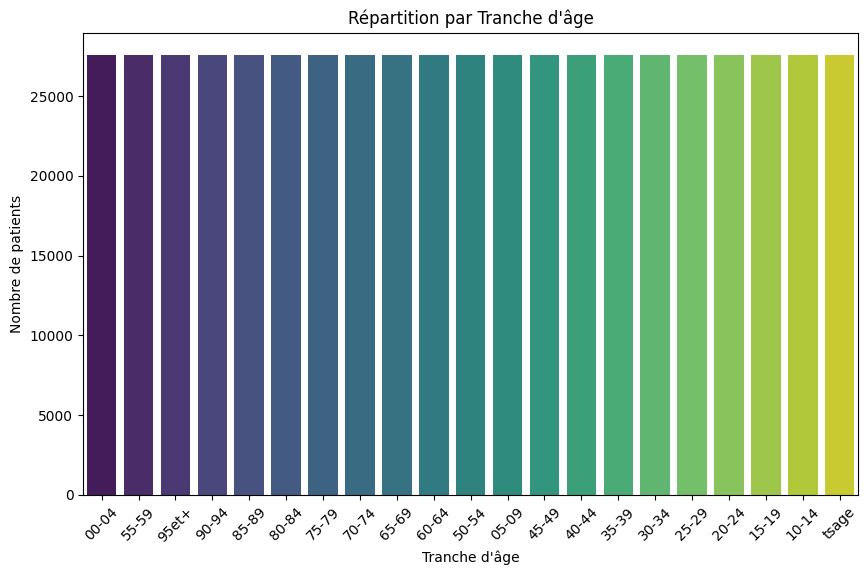

```python
import pandas as pd
import matplotlib.pyplot as plt
import seaborn as sns


# Utilisez la méthode value_counts() pour compter le nombre d'occurrences par tranche d'âge
tranche_age_counts = df_2015['cla_age_5'].value_counts()
print(tranche_age_counts)

# Créez un graphique à barres pour visualiser les tranches d'âge
plt.figure(figsize=(10, 6))
sns.barplot(x=tranche_age_counts.index, y=tranche_age_counts.values, palette="viridis")
plt.title("Répartition par Tranche d'âge")
plt.xlabel("Tranche d'âge")
plt.ylabel("Nombre de patients")
plt.xticks(rotation=45)
plt.show()
```

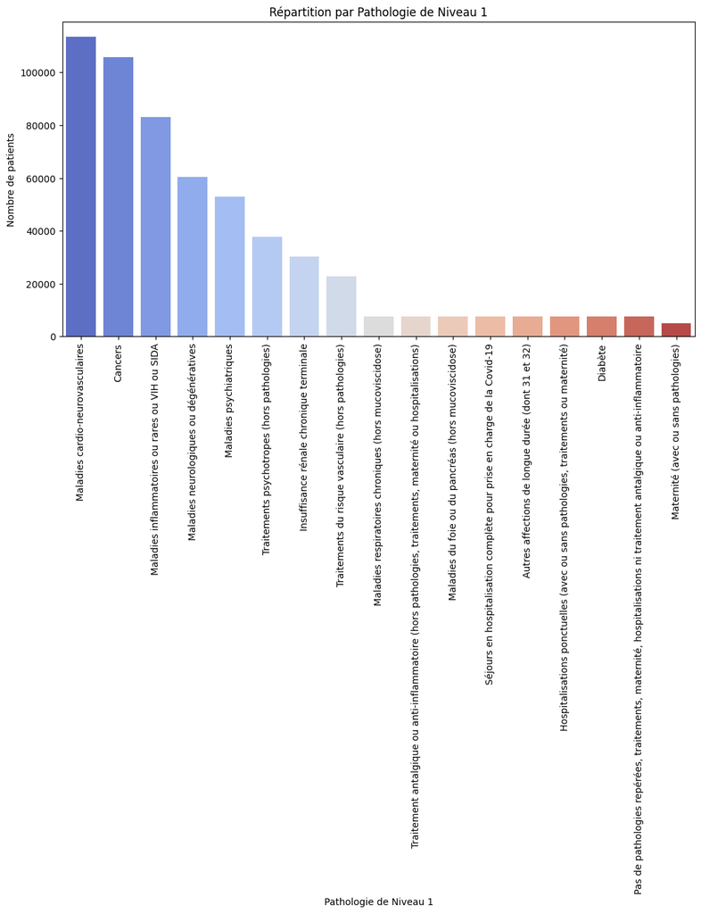

```python
# Utilisez la méthode value_counts() pour compter le nombre d'occurrences par pathologie de niveau 1
patho_niv1_counts = df_2015['patho_niv1'].value_counts()

# Créez un graphique à barres pour visualiser les différentes pathologies de niveau 1
plt.figure(figsize=(12, 6))
sns.barplot(x=patho_niv1_counts.index, y=patho_niv1_counts.values, palette="coolwarm")
plt.title("Répartition par Pathologie de Niveau 1")
plt.xlabel("Pathologie de Niveau 1")
plt.ylabel("Nombre de patients")
plt.xticks(rotation=90)
plt.show()
```

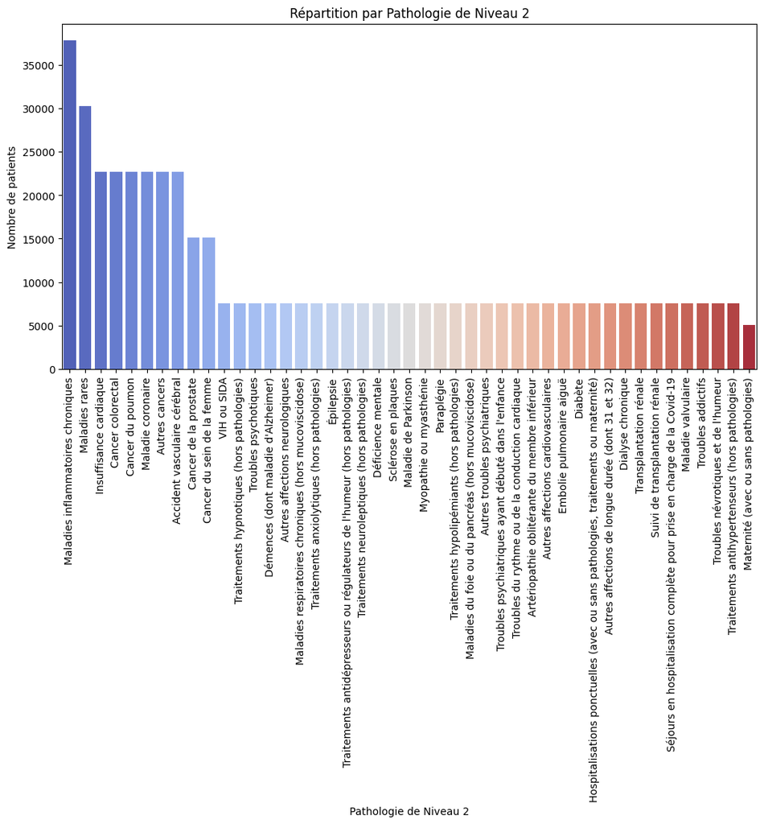

```python
# Utilisez la méthode value_counts() pour compter le nombre d'occurrences par pathologie de niveau 1
patho_niv1_counts = df_2015['patho_niv2'].value_counts()

# Créez un graphique à barres pour visualiser les différentes pathologies de niveau 1
plt.figure(figsize=(12, 6))
sns.barplot(x=patho_niv1_counts.index, y=patho_niv1_counts.values, palette="coolwarm")
plt.title("Répartition par Pathologie de Niveau 2")
plt.xlabel("Pathologie de Niveau 2")
plt.ylabel("Nombre de patients")
plt.xticks(rotation=90)
plt.show()
```

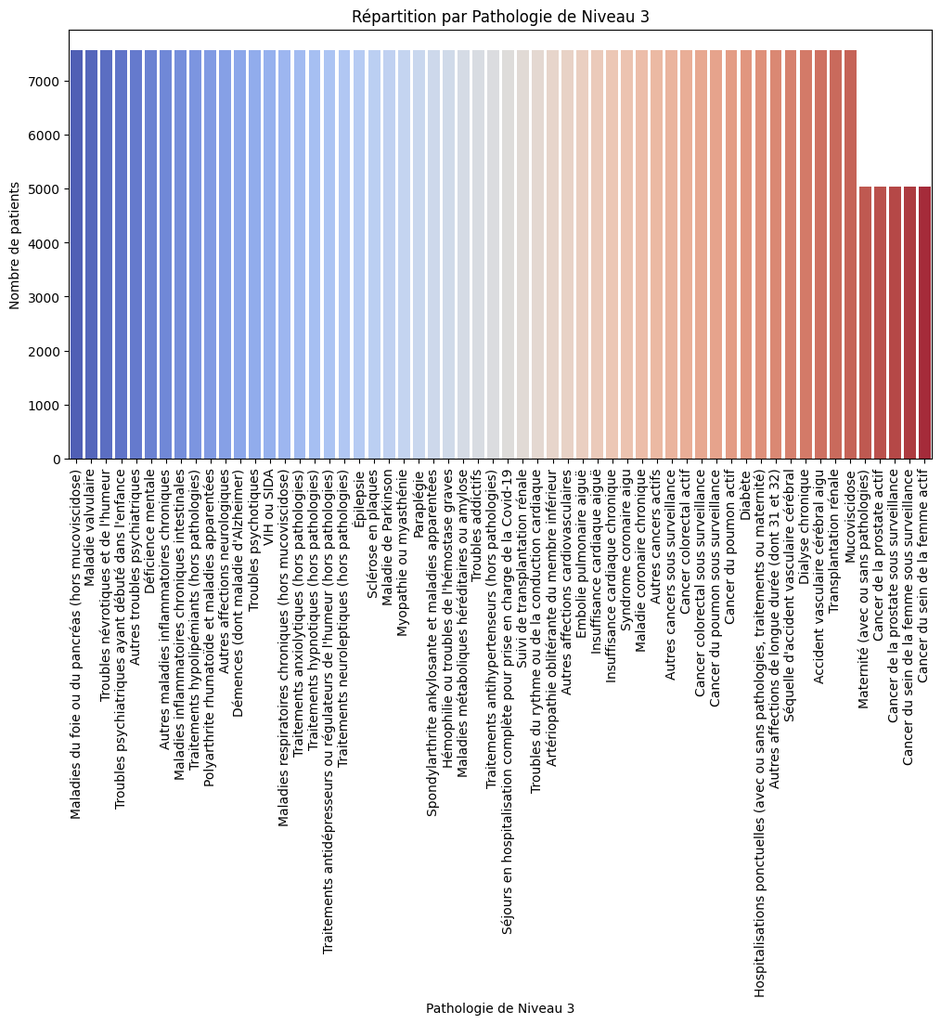

```python
# Utilisez la méthode value_counts() pour compter le nombre d'occurrences par pathologie de niveau 1
patho_niv1_counts = df_2015['patho_niv3'].value_counts()

# Créez un graphique à barres pour visualiser les différentes pathologies de niveau 1
plt.figure(figsize=(12, 6))
sns.barplot(x=patho_niv1_counts.index, y=patho_niv1_counts.values, palette="coolwarm")
plt.title("Répartition par Pathologie de Niveau 3")
plt.xlabel("Pathologie de Niveau 3")
plt.ylabel("Nombre de patients")
plt.xticks(rotation=90)
plt.show()
```

Alors on remarque que le nombre de pathologie n'est pas equivalent sur une année mais aussi que le nombre de pathologie varie en fonction du niveau de celle-ci

Notre Dataframe est trop important pour continuer l'analyse dessus, nous allons alors diviser le dataframe de facon aléatoir en essayant de garder au maximum la diversité des pathologies et les écarts

#### Enleve ligne avec valeur manquante

```python
nombre_de_valeurs_nulles = df.isna().sum()
print(nombre_de_valeurs_nulles)
```

```
annee                       1
patho_niv1              52921
patho_niv2             582121
patho_niv3            1076041
top                         1
cla_age_5                   1
sexe                        1
region                      0
dept                        0
ntop                  1091315
npop                        1
prev                  1091315
niveau_prioritaire      52921
libelle_classe_age          1
libelle_sexe                1
tri                     52921
dtype: int64
```

```python
df_trie1 = df.dropna(subset=['patho_niv1'])
```

```python
nombre_de_valeurs_nulles = df_trie1.isna().sum()
print(nombre_de_valeurs_nulles)
```

```
annee                       1
patho_niv1                  0
patho_niv2             529200
patho_niv3            1023120
top                         0
cla_age_5                   0
sexe                        0
region                      0
dept                        0
ntop                  1091314
npop                        0
prev                  1091314
niveau_prioritaire          0
libelle_classe_age          0
libelle_sexe                0
tri                         0
dtype: int64
```

```python
df_trie2 = df_trie1.dropna(subset=['annee'])
```

```python
nombre_de_valeurs_nulles = df_trie2.isna().sum()
print(nombre_de_valeurs_nulles)
```

```
annee                       0
patho_niv1                  0
patho_niv2             529200
patho_niv3            1023120
top                         0
cla_age_5                   0
sexe                        0
region                      0
dept                        0
ntop                  1091314
npop                        0
prev                  1091314
niveau_prioritaire          0
libelle_classe_age          0
libelle_sexe                0
tri                         0
dtype: int64
```

Il ligne ayant encore des valeurs manquante sont scientifiquement logique maintenant. Tous les patients n'ont pas forcement une pathologie de niveau 2 ou 3, et un manque de connaissance du nombre de patient etant atteint de la maladie ne pouvant donc pas remplir ntop et prev.

##### Pour information voici le descriptif officiel de chaque colonne

annee: annee[date] année

patho_niv1: patho_niv1[text] groupe de pathologies (ou traitements chroniques ou épisodes de soins)

patho_niv2: patho_niv2[text] sous-groupe de pathologies (ou traitements chroniques ou épisodes de soins)

patho_niv3: patho_niv3[text] sous-groupe détaillé de pathologies (ou traitements chroniques ou épisodes de soins)

top: top[text] libellé technique de la pathologie (ou traitement chronique ou épisode de soins)

cla_age_5: cla_age_5[text] classe d’âge (5 ans)

sexe: sexe[text] sexe

region: region[text] région

dept: dept[text] département

Ntop: ntop[int] effectif de patients pris en charge pour la pathologie (ou traitement chronique ou épisode de soins) dont il est question

Npop: npop[int] population de référence qui est celle de la cartographie des pathologies et des dépenses de l’Assurance Maladie

prev: prev[double] prévalence de patients pris en charge pour la pathologie (ou traitement chronique ou épisode de soins) dont il est question

Niveau prioritaire: niveau_prioritaire[text]

libelle_classe_age: libelle_classe_age[text] libellé de la classe d’âge

libelle_sexe: libelle_sexe[text] libellé du sexe

tri: tri[double]

## Création d'un dataframe plus petit

```python
import pandas as pd
import random

# Supposons que votre DataFrame s'appelle df

# Regroupez les données par année et tranche d'âge et comptez le nombre d'occurrences par groupe
counts = df.groupby(['annee', 'cla_age_5']).size().reset_index(name='count')

# Définissez le nombre maximal de lignes que vous souhaitez dans l'échantillon (moins de 5000 dans cet exemple)
max_total_samples = 40000

# Créez une liste pour stocker les échantillons aléatoires de chaque groupe
samples = []

# Pour chaque groupe (année et tranche d'âge), extrayez un échantillon aléatoire limité en taille
for _, group in counts.iterrows():
    year = group['annee']
    age_group = group['cla_age_5']
    count = group['count']

    # Calculez le nombre maximal d'échantillons à extraire pour ce groupe en fonction de la proportion
    max_num_samples = int(max_total_samples * count / len(df))

    # Sélectionnez un échantillon aléatoire limité en taille pour ce groupe
    group_data = df[(df['annee'] == year) & (df['cla_age_5'] == age_group)].sample(n=min(max_num_samples, count), random_state=42)  # Utilisez une graine aléatoire (random_state) pour la reproductibilité

    # Ajoutez l'échantillon à la liste des échantillons
    samples.append(group_data)

# Concaténez les échantillons en un nouveau DataFrame
sampled_df = pd.concat(samples)

# Maintenant, "sampled_df" contient un échantillon aléatoire avec des données équilibrées par année et par tranche d'âge, avec un maximum de 5000 lignes
```

```python
sampled_df.head()
```

|  | annee | patho_niv1 | patho_niv2 | patho_niv3 | top | cla_age_5 | sexe | region | dept | ntop | npop | prev | niveau_prioritaire | libelle_classe_age | libelle_sexe | tri |
| --- | --- | --- | --- | --- | --- | --- | --- | --- | --- | --- | --- | --- | --- | --- | --- | --- |
| 3060045 | 2015.0 | Cancers | NaN | NaN | sup_Can_cat | 00-04 | 2.0 | 44 | 52 | NaN | 4320.0 | NaN | 1 | de 0 à 4 ans | femmes | 1.0 |
| 871518 | 2015.0 | Maladies inflammatoires ou rares ou VIH ou SIDA | Maladies rares | NaN | sup_Rares_cat | 00-04 | 9.0 | 27 | 58 | 10.0 | 8950.0 | 0.134 | 2 | de 0 à 4 ans | tous sexes | 35.0 |
| 335163 | 2015.0 | Insuffisance rénale chronique terminale | NaN | NaN | sup_RIRCT_cat | 00-04 | 1.0 | 84 | 69 | NaN | 62490.0 | NaN | 1 | de 0 à 4 ans | hommes | 4.0 |
| 949925 | 2015.0 | Insuffisance rénale chronique terminale | NaN | NaN | sup_RIRCT_cat | 00-04 | 1.0 | 76 | 09 | NaN | 3490.0 | NaN | 1 | de 0 à 4 ans | hommes | 4.0 |
| 1091915 | 2015.0 | Maladies psychiatriques | Autres troubles psychiatriques | Autres troubles psychiatriques | top_PsyAutr_ind | 00-04 | 2.0 | 75 | 16 | NaN | 8120.0 | NaN | 2,3 | de 0 à 4 ans | femmes | 49.0 |

```python
sampled_df.shape
```

```
(39984, 16)
```

```python
sampled_df.describe()
```

|  | annee | sexe | region | ntop | npop | prev | tri |
| --- | --- | --- | --- | --- | --- | --- | --- |
| count | 39984.000000 | 39984.000000 | 39984.000000 | 2.923800e+04 | 3.998400e+04 | 29238.000000 | 39417.000000 |
| mean | 2018.000000 | 4.075880 | 51.084284 | 7.533817e+03 | 1.056466e+05 | 6.458080 | 39.541771 |
| std | 2.000025 | 3.591194 | 29.402844 | 3.916293e+05 | 1.085032e+06 | 16.569619 | 22.541599 |
| min | 2015.000000 | 1.000000 | 1.000000 | 1.000000e+01 | 2.000000e+01 | 0.001000 | 1.000000 |
| 25% | 2016.000000 | 1.000000 | 27.000000 | 5.000000e+01 | 7.720000e+03 | 0.273000 | 20.000000 |
| 50% | 2018.000000 | 2.000000 | 52.000000 | 2.000000e+02 | 1.703000e+04 | 0.945000 | 40.000000 |
| 75% | 2020.000000 | 9.000000 | 76.000000 | 9.375000e+02 | 4.292000e+04 | 4.260750 | 58.000000 |
| max | 2021.000000 | 9.000000 | 99.000000 | 6.550960e+07 | 6.550960e+07 | 100.000000 | 78.000000 |

```python
for a in range (2015,2022):
    filtre = sampled_df['annee'] == a
    nombre_de_lignes = len(sampled_df[filtre])
    print("Nombre de lignes avec de l'année ",a ," : ", nombre_de_lignes)
```

```
Nombre de lignes avec de l'année  2015  :  5712
Nombre de lignes avec de l'année  2016  :  5712
Nombre de lignes avec de l'année  2017  :  5712
Nombre de lignes avec de l'année  2018  :  5712
Nombre de lignes avec de l'année  2019  :  5712
Nombre de lignes avec de l'année  2020  :  5712
Nombre de lignes avec de l'année  2021  :  5712
```

```python
sampled_df_2015= sampled_df[sampled_df['annee'] == 2015]
sampled_df_2015.head()
```

|  | annee | patho_niv1 | patho_niv2 | patho_niv3 | top | cla_age_5 | sexe | region | dept | ntop | npop | prev | niveau_prioritaire | libelle_classe_age | libelle_sexe | tri |
| --- | --- | --- | --- | --- | --- | --- | --- | --- | --- | --- | --- | --- | --- | --- | --- | --- |
| 3060045 | 2015.0 | Cancers | NaN | NaN | sup_Can_cat | 00-04 | 2.0 | 44 | 52 | NaN | 4320.0 | NaN | 1 | de 0 à 4 ans | femmes | 1.0 |
| 871518 | 2015.0 | Maladies inflammatoires ou rares ou VIH ou SIDA | Maladies rares | NaN | sup_Rares_cat | 00-04 | 9.0 | 27 | 58 | 10.0 | 8950.0 | 0.134 | 2 | de 0 à 4 ans | tous sexes | 35.0 |
| 335163 | 2015.0 | Insuffisance rénale chronique terminale | NaN | NaN | sup_RIRCT_cat | 00-04 | 1.0 | 84 | 69 | NaN | 62490.0 | NaN | 1 | de 0 à 4 ans | hommes | 4.0 |
| 949925 | 2015.0 | Insuffisance rénale chronique terminale | NaN | NaN | sup_RIRCT_cat | 00-04 | 1.0 | 76 | 09 | NaN | 3490.0 | NaN | 1 | de 0 à 4 ans | hommes | 4.0 |
| 1091915 | 2015.0 | Maladies psychiatriques | Autres troubles psychiatriques | Autres troubles psychiatriques | top_PsyAutr_ind | 00-04 | 2.0 | 75 | 16 | NaN | 8120.0 | NaN | 2,3 | de 0 à 4 ans | femmes | 49.0 |

```
cla_age_5
00-04    272
55-59    272
95et+    272
90-94    272
85-89    272
80-84    272
75-79    272
70-74    272
65-69    272
60-64    272
50-54    272
05-09    272
45-49    272
40-44    272
35-39    272
30-34    272
25-29    272
20-24    272
15-19    272
10-14    272
tsage    272
Name: count, dtype: int64
```

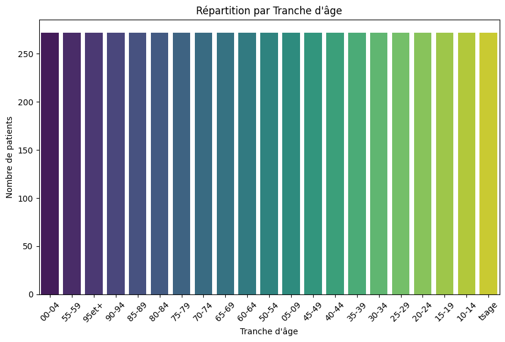

```python
import pandas as pd
import matplotlib.pyplot as plt
import seaborn as sns


# Utilisez la méthode value_counts() pour compter le nombre d'occurrences par tranche d'âge
tranche_age_counts = sampled_df_2015['cla_age_5'].value_counts()
print(tranche_age_counts)

# Créez un graphique à barres pour visualiser les tranches d'âge
plt.figure(figsize=(10, 6))
sns.barplot(x=tranche_age_counts.index, y=tranche_age_counts.values, palette="viridis")
plt.title("Répartition par Tranche d'âge")
plt.xlabel("Tranche d'âge")
plt.ylabel("Nombre de patients")
plt.xticks(rotation=45)
plt.show()
```

Dispersion des données dans notre nouveau dataframes bien effectuer maintenant il faut verifier qu'on a garder le bon nombre d'information sur les pathologies

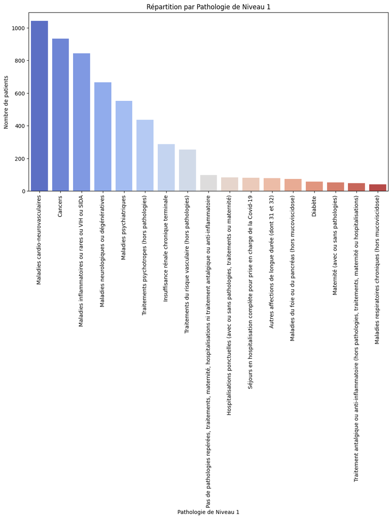

```python
# Utilisez la méthode value_counts() pour compter le nombre d'occurrences par pathologie de niveau 1
patho_niv1_counts = sampled_df_2015['patho_niv1'].value_counts()

# Créez un graphique à barres pour visualiser les différentes pathologies de niveau 1
plt.figure(figsize=(12, 6))
sns.barplot(x=patho_niv1_counts.index, y=patho_niv1_counts.values, palette="coolwarm")
plt.title("Répartition par Pathologie de Niveau 1")
plt.xlabel("Pathologie de Niveau 1")
plt.ylabel("Nombre de patients")
plt.xticks(rotation=90)
plt.show()
```

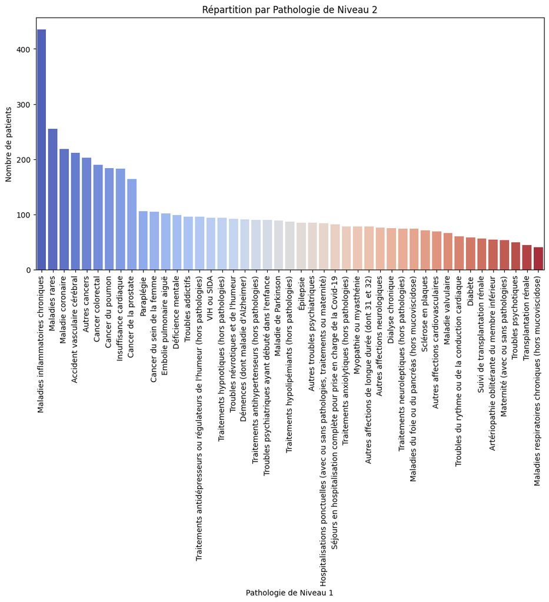

```python
# Utilisez la méthode value_counts() pour compter le nombre d'occurrences par pathologie de niveau 1
patho_niv1_counts = sampled_df_2015['patho_niv2'].value_counts()

# Créez un graphique à barres pour visualiser les différentes pathologies de niveau 1
plt.figure(figsize=(12, 6))
sns.barplot(x=patho_niv1_counts.index, y=patho_niv1_counts.values, palette="coolwarm")
plt.title("Répartition par Pathologie de Niveau 2")
plt.xlabel("Pathologie de Niveau 1")
plt.ylabel("Nombre de patients")
plt.xticks(rotation=90)
plt.show()
```

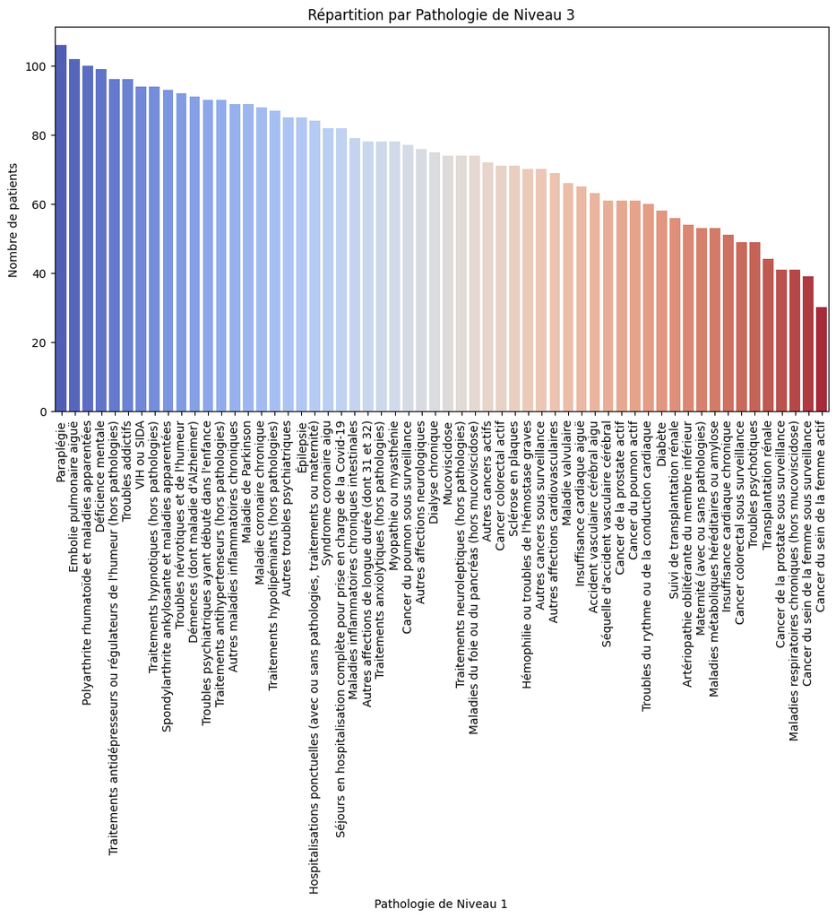

```python
# Utilisez la méthode value_counts() pour compter le nombre d'occurrences par pathologie de niveau 1
patho_niv1_counts = sampled_df_2015['patho_niv3'].value_counts()

# Créez un graphique à barres pour visualiser les différentes pathologies de niveau 1
plt.figure(figsize=(12, 6))
sns.barplot(x=patho_niv1_counts.index, y=patho_niv1_counts.values, palette="coolwarm")
plt.title("Répartition par Pathologie de Niveau 3")
plt.xlabel("Pathologie de Niveau 1")
plt.ylabel("Nombre de patients")
plt.xticks(rotation=90)
plt.show()
```

##### Exportation du nouvel sous ensemble

```python
sampled_df.to_csv("echantillons_trie.csv", index=False)  # L'argument index=False permet de ne pas inclure les indices de lignes dans le fichier CSV
```